# Grab-bag part 2

# Today’s plan

1. Spatial sampling
2. Landscape metrics
3. Some basic statistics

# Activities

## Setup

Load some packages

```r
library(landscapemetrics) # new - you'll likely need to install this package
```

## Raster data

LULC data for NE OH

```r
neoh_lulc <- terra::rast("../data/ohio/neoh_nlcd.tif")

# summary
terra::summary(neoh_lulc)
```

```
           NLCD.Land.Cover.Class
 Open Water           :21768
 Deciduous Forest     :20420
 Unclassified         :14456
 Hay/Pasture          :12179
 Cultivated Crops     :10119
 Developed, Open Space: 5850
 (Other)              :15566
```

## Vector data

```r
# using terra vector classes to make later operations easier
# project to the crs of the raster so we don't need to resample raster (which takes forever)
neoh_counties <- vect("../data/ohio/neoh_counties.gpkg") %>%
  terra::project(., crs(neoh_lulc))

oh_tracts <- vect("../data/ohio/oh_tracts_2020.gpkg") %>%
  terra::project(., crs(neoh_lulc))
```

Let’s define a spatial subset so that our initial work is faster

```r
portage <- neoh_counties %>% tidyterra::filter(NAME == "Portage")

summit <- neoh_counties %>% tidyterra::filter(NAME == "Summit")


mapview(portage, label = "NAME", fill = "Red") +
  mapview(summit, label = "NAME", fill = "Green")
```

[output not shown]

Let’s clip the raster to Portage County

```r
lulc.portage <- neoh_lulc %>% terra::crop(., portage) %>%
  terra::mask(., portage)


mapview(portage) + mapview(lulc.portage)
```

```
Number of pixels is above 5e+05.Only about 5e+05 pixels will be shown.
You can increase the value of `maxpixels` to 1908054 to avoid this.
```

What’s the deal with the shape of the raster?

Let’s add a mask

```r
masked.portage <- lulc.portage %>% terra::mask(., portage)
```

Wait, what’s the difference between a `crop` and a `mask`?

```r
dim(lulc.portage)
```

```
[1] 1493 1278    1
```

```r
dim(masked.portage)
```

```
[1] 1493 1278    1
```

Let’s try something else. How many NA values in each?

```r
lulc.portage %>% values() %>% as_tibble() %>% dplyr::filter(is.na(`NLCD Land Cover Class`)) %>% nrow()
```

[output not shown]

```r
masked.portage %>% values() %>% as_tibble() %>% dplyr::filter(is.na(`NLCD Land Cover Class`)) %>% nrow()
```

```
[1] 454748
```

So, what’s the difference between a `crop` and a `mask`?

What are some alternatives to using these approaches?

## Landscape metrics

What’s a landscape metric?

### Some common metrics

#### 1. **Patch Density (PD)**

- **Description:** Measures the number of patches per unit area. It provides insight into the fragmentation of a landscape—more patches generally indicate more fragmentation.
- **Interpretation:** Higher values suggest a more fragmented or heterogeneous landscape.

#### 2. **Edge Density (ED)**

- **Description:** Total length of all edge segments in the landscape per unit area. This metric quantifies the amount of edge habitat, which can be important for certain species.
- **Interpretation:** A high edge density often implies a fragmented landscape with many small patches or irregular shapes.

#### 3. **Mean Patch Size (MPS)**

- **Description:** The average area of patches within a given class or the whole landscape. It provides a simple summary of patch area characteristics.
- **Interpretation:** Larger mean patch sizes suggest greater habitat continuity or core area.

#### 4. **Landscape Shape Index (LSI)**

- **Description:** Measures the complexity of patch shapes relative to a standard shape (square or circle). It accounts for both the number and perimeter of patches.
- **Interpretation:** Higher LSI values indicate more irregular or complex patch shapes.

#### 5. **Shannon’s Diversity Index (SHDI)**

- **Description:** A diversity index that accounts for both the richness and evenness of patch types in the landscape.
- **Interpretation:** Higher SHDI values indicate greater landscape heterogeneity and compositional complexity.

Let’s try a few

[output not shown]

[output cut: 5 more lines]

Mean patch size. Anything different here?

```r
# Mean patch size

## Landscape level
landscapemetrics::lsm_l_area_mn(lulc.portage, directions = 8)
```

| layer | level | class | id | metric | value |
| --- | --- | --- | --- | --- | --- |
| 1 | landscape | NA | NA | area_mn | 1.870132 |

```r
## Class level
landscapemetrics::lsm_c_area_mn(lulc.portage, directions = 8)
```

| layer | level | class | id | metric | value |
| --- | --- | --- | --- | --- | --- |
| 1 | class | 11 | NA | area_mn | 3.3430586 |
| 1 | class | 21 | NA | area_mn | 0.6232938 |
| 1 | class | 22 | NA | area_mn | 0.7757427 |
| 1 | class | 23 | NA | area_mn | 0.5421560 |
| 1 | class | 24 | NA | area_mn | 0.5956565 |
| 1 | class | 31 | NA | area_mn | 0.7707182 |
| 1 | class | 41 | NA | area_mn | 10.3463303 |
| 1 | class | 42 | NA | area_mn | 0.8320755 |
| 1 | class | 43 | NA | area_mn | 0.5840091 |
| 1 | class | 52 | NA | area_mn | 0.7888863 |

[output cut: 5 more lines]

Indices

```r
# Shannon's
landscapemetrics::lsm_l_shdi(lulc.portage)
```

| layer | level | class | id | metric | value |
| --- | --- | --- | --- | --- | --- |
| 1 | landscape | NA | NA | shdi | 1.990965 |

```r
# Simpson's
landscapemetrics::lsm_l_sidi(lulc.portage)
```

| layer | level | class | id | metric | value |
| --- | --- | --- | --- | --- | --- |
| 1 | landscape | NA | NA | sidi | 0.8085375 |

```r
# Landscape shape index
landscapemetrics::lsm_l_lsi(lulc.portage)
```

| layer | level | class | id | metric | value |
| --- | --- | --- | --- | --- | --- |
| 1 | landscape | NA | NA | lsi | 185.1046 |

```r
landscapemetrics::lsm_c_lsi(lulc.portage)
```

| layer | level | class | id | metric | value |
| --- | --- | --- | --- | --- | --- |
| 1 | class | 11 | NA | lsi | 34.29249 |
| 1 | class | 21 | NA | lsi | 209.64319 |
| 1 | class | 22 | NA | lsi | 188.17276 |
| 1 | class | 23 | NA | lsi | 126.91195 |
| 1 | class | 24 | NA | lsi | 54.63878 |
| 1 | class | 31 | NA | lsi | 25.77372 |
| 1 | class | 41 | NA | lsi | 126.39767 |
| 1 | class | 42 | NA | lsi | 30.16429 |
| 1 | class | 43 | NA | lsi | 108.93915 |
| 1 | class | 52 | NA | lsi | 35.73988 |

[output cut: 5 more lines]

```r
NA
NA
```

## A bit of stats

Let’s figure out the landscape diversity of all Census tracts in Portage County

### CONCEPTUAL MODELING ON THE WHITEBOARD!!!

. . . . . . . . . .. SPOILER WARNING….. . . . . . . . . . .. SPOILER WARNING….. . . . . . . . . .. SPOILER WARNING….. . . . . . . . . .. SPOILER WARNING….. . . . . . . . .

### Let’s work it out

We can grab any given tract, crop the raster to it, and calculate a metric

[output not shown]

So let’s develop a function to automate

```r
calc_shannon <- function(r, v){

  toReturn <- terra::crop(r, v) %>%
    landscapemetrics::lsm_l_shdi(.)

  return(toReturn)
}
```

Test it

```r
calc_shannon(lulc.portage, pc.tracts[1])
```

| layer | level | class | id | metric | value |
| --- | --- | --- | --- | --- | --- |
| 1 | landscape | NA | NA | shdi | 1.185129 |

It works!

But it’s a hassle to manually go one-by-one. Options?

. .. … …. ….. …… …….

Frustratingly, terra doesn’t easily allow iterating over rows (sf objects do).

WHY???!?!!?!?!?!

So we have to create a wrapper function around `calc_shannon`

…AND THEN iterate over the tracts using their index.

```r
calc_shannon_wrapper <- function(i, r, tracts) {
  v <- tracts[i, ]
  res <- calc_shannon(r, v)
  res$GEOID <- i
  return(res)
}
```

So we use `map()` functions to iterate over the tracts, call the wrapper function, which then calls the other function

```r
results <- map_dfr(1:nrow(pc.tracts), calc_shannon_wrapper, r = lulc.portage, tracts = pc.tracts)
```

### Trade-offs among packages and data types/models

This is why I like sf() better - it treats spatial objects like tibbles()

```r
# Define a modified version of your function that works with one row of sf
calc_shannon_sf <- function(r, v_geom) {
  v_vect <- terra::vect(v_geom)  # Convert sf geometry to SpatVector - WE DO HAVE TO CONVERT TO TERRA STILL
  toReturn <- terra::crop(r, v_vect) %>%
    landscapemetrics::lsm_l_shdi(.)
  return(toReturn$value)
}

# Use rowwise mutate to apply to each feature
portage_tracts_sf <- pc.tracts %>%
  as_sf() %>%
  rowwise() %>%
  mutate(shdi = calc_shannon_sf(lulc.portage, geometry)) %>%
  ungroup()
```

Regardless of how we do it, we now have the SHDI values for each tract.

So let’s plot it

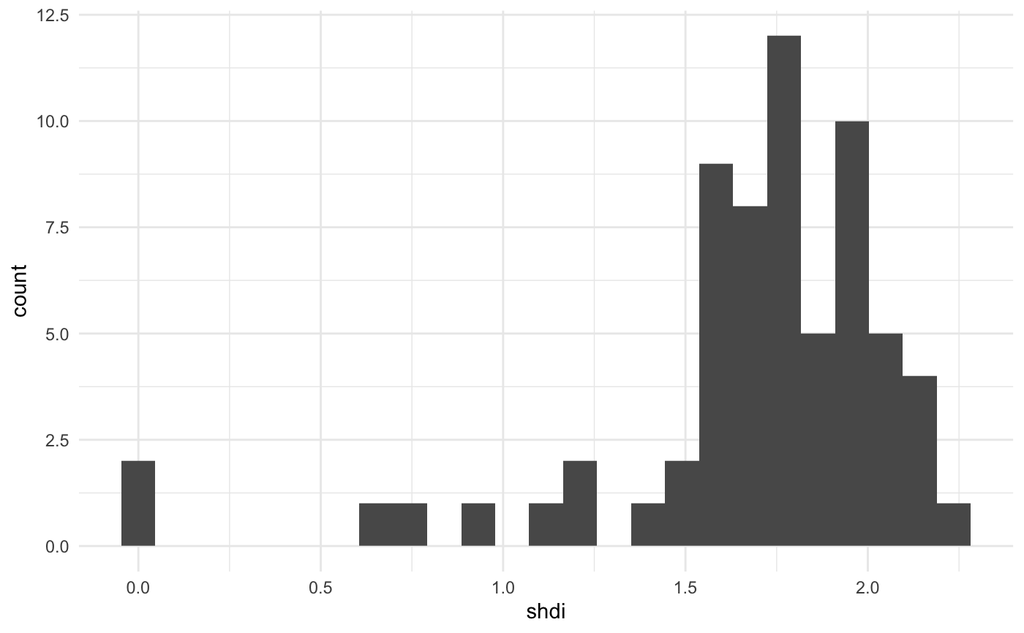

```r
portage_tracts_sf %>%
  ggplot(., aes(x = shdi)) +
  geom_histogram(bins = 25) +
  theme_minimal()
```

What can we infer from this plot? Anything?

Let’s make a comparison between two counties

Reuse the function for Summit County

Get the data ready first

```r
sc.tracts <- terra::intersect(oh_tracts, summit)
lulc.sc <- neoh_lulc %>% terra::crop(., summit)

# map it to make sure we have what we want
mapview(lulc.sc) + mapview(sc.tracts)
```

```
Number of pixels is above 5e+05.Only about 5e+05 pixels will be shown.
You can increase the value of `maxpixels` to 1646730 to avoid this.
```

Then run for Summit county

```r
summit_tracts_sf <- sc.tracts %>%
  as_sf() %>%
  rowwise() %>%
  mutate(shdi = calc_shannon_sf(lulc.sc, geometry)) %>%
  ungroup()
```

Then plot it too!

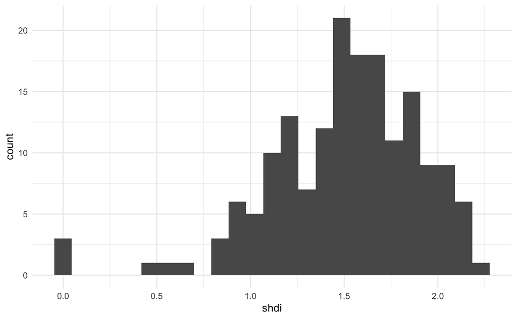

```r
summit_tracts_sf %>%
  ggplot(., aes(x = shdi)) +
  geom_histogram(bins = 25) +
  theme_minimal()
```

Let’s make a comparison. First, we put the data together to make it easier

```r
both_sf <- bind_rows(portage_tracts_sf, summit_tracts_sf)

mapview(both_sf, zcol = "shdi")
```

Now let’s plot the differences

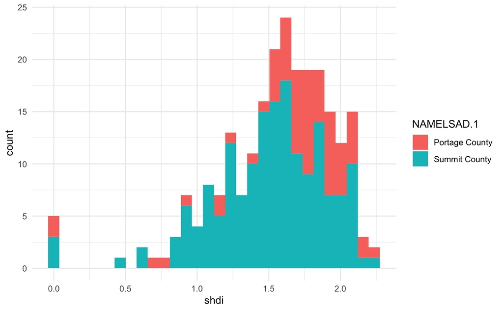

```r
both_sf %>%
  ggplot(., aes(x = shdi, fill = NAMELSAD.1)) +
  geom_histogram() +
  theme_minimal()
```

Hmmm, a bit hard to interpret

Options?

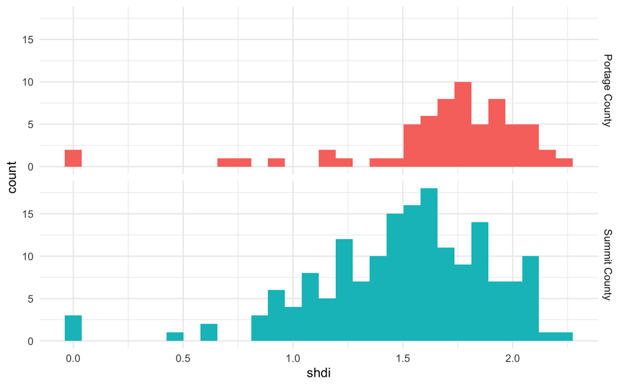

```r
both_sf %>%
  ggplot(., aes(x = shdi, fill = NAMELSAD.1)) +
  geom_histogram() +
  theme_minimal() +
  theme(legend.position = "none") +
  facet_grid(NAMELSAD.1~.)
```

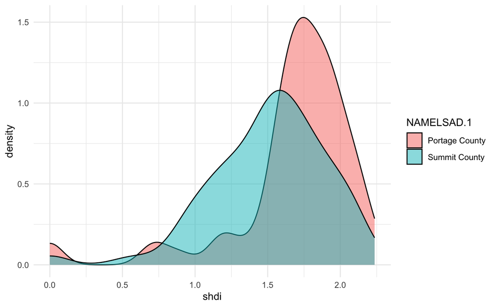

# Let’s do some stats

## Purpose

To test the **null hypothesis** that the means of all groups are equal:

$$H_0: \mu_1 = \mu_2 = \mu_3 = \dots = \mu_k$$

Against the **alternative hypothesis** that at least one group mean is different.

## How It Works

ANOVA compares the **variance between group means** to the **variance within the groups**:

- **Between-group variability**: How much the group means deviate from the overall mean.
- **Within-group variability**: How much individual observations deviate from their group mean.

The test statistic is an **F-ratio**:

$$F = \frac{\text{Mean Square Between Groups}}{\text{Mean Square Within
Groups}}$$

A larger F value indicates more variability **between groups** than **within**, suggesting group means are not all equal.

## Output

Typically includes:

- **F-statistic**
- **p-value**
- **Degrees of freedom** for between-group and within-group variation

If the p-value is **less than the chosen significance level** (e.g., 0.05), reject the null hypothesis.

## Post Hoc Tests

If ANOVA is significant, post hoc comparisons (e.g., Tukey’s HSD) are used to determine **which groups differ**.

```r
# Post hoc
TukeyHSD(model)
```

[output not shown]

```
  Tukey multiple comparisons of means
    95% family-wise confidence level

Fit: aov(formula = shdi ~ NAMELSAD.1, data = both_sf)

$NAMELSAD.1
                                   diff        lwr         upr     p adj
Summit County-Portage County -0.1774161 -0.2953357 -0.05949656 0.0033491
```

# Your tasks

1. Add another county to the analysis. Run the ANOVA again
2. How might we modify/extend our analysis to another statistic? Try it!